# Homework 8

# Submission Instructions

- Submit responses in a .ipynb file.
- For calculation questions:
  - Include R code used.
  - Ensure all code has been executed to display output.
  - Round *answers* to 3-5 decimal places if necessary.
  - Avoid displaying unnecessary R outputs.
  - Support conclusions with plots when checking assumptions.
  - Assume $\alpha = 0.05$ unless stated otherwise.
  - Two-sided hypothesis tests require two-sided confidence intervals.
  - One-sided hypothesis tests require one-sided confidence intervals.

# Question 1

The data contained in **“lake.csv”**, reports the data of 29 lakes in Florida and contains three variables:

- NIN = Average influent nitrogen concentration.
- TN = Mean annual total nitrogen concentration.
- TW = Water retention time.

The outcome the research was interested in was TN.

The lake data is going to be used to create a linear model with two predictors. Use the MAD-Median Rule to appropriately remove outliers from the data.

List the outliers (i.e., rows) that have been removed for **both** predictors and use the outlier-free data for the remaining questions.

You are allowed to use the function `mad()`.

```r
library(tidyverse)
lake <- read_csv("../Data/lake.csv")

# Search for outliers in the two predictors:
# NIN
lake$NIN_out <- abs(lake$NIN - median(lake$NIN)) / mad(lake$NIN) > 2.24

# TW
lake$TW_out <- abs(lake$TW - median(lake$TW)) / mad(lake$TW) > 2.24

# Remove the outliers from the data set.
  # There are different ways you could achieve this.
  # Note that the entire row gets removed to prevent missing values.
lake_cln <- lake |>
  filter(NIN_out == FALSE & TW_out == FALSE) |>
  select(NIN, TN, TW)

# Print the outlier values/rows
lake |>
  filter(NIN_out == TRUE | TW_out == TRUE) |>
  select(NIN, TN, TW)
```

```
## # A tibble: 6 × 3
##      NIN    TN    TW
##    <dbl> <dbl> <dbl>
## 1  4.896 3.77  2.499
## 2  3.586 1.445 1.699
## 3  3.557 1.25  1.699
## 4 18.05  1.096 2.899
## 5  4.81  1.745 3.4
## 6 34.32  1.965 1.499
```

# Question 2

Fit two linear regression models to predict TN with the new outlier-free data set. One model should use NIN as a predictor, the other model should use both NIN and TW as a predictor. Report the formula (i.e., with calculated $b$ values) for both models you create.

Please ensure clarity when referencing predictors within the formulas. i.e., don’t just write $x_1$, provide clear labels:

- e.g., $... + (b \text{ value}) \cdot \text{NIN}$
- e.g., $... + (b\text{ value}) \cdot X_\text{NIN}$

```r
mod1 <- lm(TN ~ NIN, data = lake_cln)
mod2 <- lm(TN ~ NIN + TW, data = lake_cln)
```

**Formulas:**

$\hat{y} = 0.199 + 0.632 \cdot \text{NIN}$

$\hat{y} = 0.649 + 0.583 \cdot \text{NIN} + (-0.988) \cdot \text{TW}$

# Question 3

As we learned in class, the `summary()` function can be used to extract various information about a linear model, such as whether the coefficients are significantly different than 0. Find a way to extract only the un-rounded “*Std. Error*” statistic that the `summary()` function displays for the TW predictor.

- Hint: `$` `[ ]`

```r
summary(mod2)$coefficients[3, 2]
```

```
## [1] 0.878838034827209
```

# Question 4

Does the model with only a single predictor have a slope significantly different than 0?

- Write R code to extract the p-value for the slope.
- Report the confidence interval around the slope. Use of the function `confint()` is prohibited.

```r
#1 Predictor TN ~ NIN Model
mod1sum <- summary(mod1)

#Storing P-value
p_val <- mod1sum$coefficients[2, 4]

# Degrees of freedom
N <- nrow(lake_cln)
P <- 1
df <- N - P - 1

# Stats for Confidence Interval
b1 <- mod1sum$coefficients[2, 1] # slope
se <- mod1sum$coefficients[2, 2]
alpha <- 0.05
t_crit <- abs(qt(alpha/2, df))

# Confidence Interval
bot <- b1 - se * t_crit
top <- b1 + se * t_crit
```

```
## NIN: p = 0.0002723962
```

```
## NIN 95% CI: [0.3309, 0.9334]
```

The single predictor NIN has a slope significantly different than 0.

# Question 5

Does the model with two predictors contain slopes significantly different than 0?

- Write R code to extract the p-value for *each predictor’s* slope.
- Report the confidence interval around *each predictor’s* slope. Use of the function `confint()` is prohibited.

```r
#2 Predictor TN ~ NIN + TW Model
mod2sum <- summary(mod2)

#Storing P-values
p_NIN <- mod2sum$coefficients[2, 4]
p_TW <- mod2sum$coefficients[3, 4]

# Degrees of freedom
N <- nrow(lake_cln)
P <- 2
df <- N - P - 1 # Note that the df changed

# Confidence Intervals
alpha <- 0.05
t_crit <- abs(qt(alpha/2, df))

# NIN CI
b1 <- mod2sum$coefficients[2, 1]
se_NIN <- mod2sum$coefficients[2, 2]

bot_NIN <- b1 - se_NIN * t_crit
top_NIN <- b1 + se_NIN * t_crit


# TW CI
b2 <- mod2sum$coefficients[3, 1]
se_TW <- mod2sum$coefficients[3, 2]

bot_TW <- b2 - se_TW * t_crit
top_TW <- b2 + se_TW * t_crit
```

```
## NIN: p = 0.0009368245
```

```
## NIN 95% CI: [0.2694, 0.8969]
```

```
## TW: p = 0.2740956
```

```
## TW 95% CI: [-2.8215, 0.8449]
```

Only the predictor NIN has a slope significantly different than 0.

# Question 6

Conduct a test to determine whether the additional predictor in the second model significantly improves the fit relative to the single-predictor model.

- Does the second predictor significantly improve the model?
- Report the test-statistic, degrees of freedom, and p-value.
- Use of `anova()` is prohibited.

```r
N <- nrow(lake_cln)
P_modB <- 2
P_diff <- 2 - 1
Rsq_diff <- mod2sum$r.squared - mod1sum$r.squared

# F-statistic to compare the models
F_stat <- ((N - P_modB - 1) / P_diff) * (Rsq_diff / (1 - mod2sum$r.squared))

# p-value
df1 <- P_diff
df2 <- N - P_modB - 1

p <- pf(F_stat, df1 = df1, df2 = df2, lower.tail = FALSE)
```

```
## F =  1.265
```

```
## df1 = 1; df2 = 20
```

```
## p =  0.274
```

The second predictor does not significantly improve the model.

# Question 7

Assume that a lake has an average influent nitrogen concentration of 5.7 and a water retention time of 0.98. Use the preferred model, as determined from the previous question, to predict the annual nitrogen concentration of that lake.

```r
x <- 5.7
y <- mod1$coefficients[1] + mod1$coefficients[2] * x

unname(y)
```

```
## [1] 3.801665
```

The annual nitrogen concentration of the lake is predicted to be 3.8017.

- *Note: Since the F-test comparing the model fits was not significantly different, the simpler model is preferred.*

# Question 8

A psychologist studying perceived “quality of life” in a large number of cities came up with the following equation using mean temperature ($^{\circ}$F) and median income in $1,000 as predictors.

$$\hat{Y} = 5.37 - 0.01 \cdot \text{Temp}
+ 0.05 \cdot \text{Income}$$

Interpret the regression equation in terms of the coefficients. i.e., State what each predictor of the model means in plain English.

- All other variables held constant, a difference of +1 degree in Temperature is associated with a 0.01 decline in perceived Quality of Life.
- A difference of $1,000 in median Income, again with all other variables held constant, is associated with a 0.05 increase in perceived Quality of Life.
- The intercept: when temperature and income are both 0, there is still expected to be a perceived quality of life of 5.37.
- *Note that there are many different ways these statements could be expressed.*

# Question 9

Using the model from the previous question, assume a city has a mean temperature of 55 degrees and a median income of $12,000. What is its predicted Quality of Life score?

```r
Temp <- 55
Income <- 12

y <- 5.37 - 0.01 * Temp + 0.05 * Income
y
```

```
## [1] 5.42
```

# Question 10

You are a highfalutin marketing guru who wants to predict the sales of your brand using the data set **DataDrivenMarketing.csv**. However, there are a number of missing `NA` values in this data set. Using what you know about R, and (if necessary) your Googling skills, report how many `NA` values are in each of the dataset’s columns.

- Note that there are many different ways to achieve this.

Here is one simple, yet **inefficient** option:

```r
ddm <- read_csv("../Data/DataDrivenMarketing.csv")

nrow(filter(ddm, is.na(TV))) #TV
nrow(filter(ddm, is.na(Radio))) #Radio
nrow(filter(ddm, is.na(Social.Media))) #Social Media
nrow(filter(ddm, is.na(Influencer))) #Influencer
nrow(filter(ddm, is.na(Sales))) #Sales
```

```
## [1] 0
## [1] 8
## [1] 7
## [1] 5
## [1] 5
```

The best option is to just use …

```r
colSums(is.na(ddm))
```

```
##           TV        Radio Social.Media   Influencer        Sales
##            0            8            7            5            5
```

- This works because `is.na()` returns a `TRUE` if a value in the data frame is `NA` and `FALSE` if it is not `NA.` In R, `TRUE` = 1 and `FALSE` = 0. So you can count the amount of `TRUE` by taking the sum. E.g., `TRUE + TRUE + FALSE` = 2. The function `colSums()` just takes the sum of each column.

# Question 11

Using the **DataDrivenMarketing.csv** data, create a dataframe that removes any **row** which has a `NA` value.

Report how many rows this new data frame has. There are numerous ways to achieve this, none of which should be overly complicated - so if you are typing lots of code to solve this question, you are doing it wrong. **Use this cleaned up data set for all subsequent questions.**

```r
ddm_cln <- na.omit(ddm)
nrow(ddm_cln)
```

```
## [1] 4524
```

# Question 12

Plot a correlation matrix of the possible (**quantitative**) predictors you could include in your model that predicts sales. Make sure the correlation values are also shown either inside the plot or as a separate output.

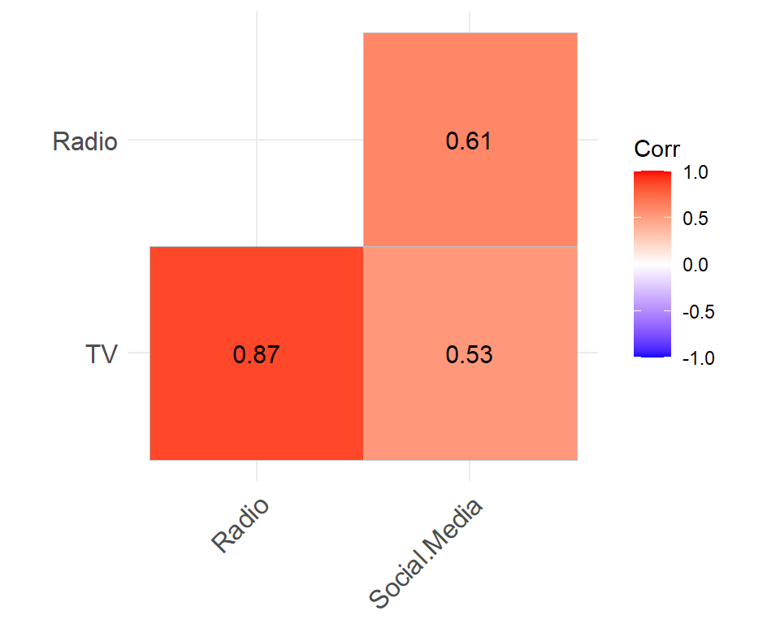

```r
library(ggcorrplot)

corrs <- cor(ddm_cln[, 1:3])

ggcorrplot(corrs, lab = TRUE, type = "lower")
```

# Question 13

Because multicolinearity appears as though it could be an issue you decide to check the variance inflation factors.

Compare the variance inflation factors of a model with all 3 quantitative predictors:

$$\text{Sales} = b_0 + b_1 \cdot
\text{(TV)} + b_2 \cdot \text{(Radio)} + b_3 \cdot \text{(Social
Media)}$$

… to a model with just TV and social media:

$$\text{Sales} = b_0 + b_1 \cdot
\text{(TV)} + b_2 \cdot \text{(Social Media)}$$

Report the VIF scores for each model.

```r
library(car)

mod3 <- lm(Sales ~ TV + Radio + Social.Media, data = ddm_cln)
mod2 <- lm(Sales ~ TV + Social.Media, data = ddm_cln)

# Model with 3 predictors
vif(mod3)
```

```
##           TV        Radio Social.Media
##     4.082129     4.656350     1.578171
```

```r
# Model with 2 predictors
vif(mod2)
```

```
##           TV Social.Media
##     1.383548     1.383548
```

# Question 14

You want to perform a hierarchical regression. Use the MAD-median rule to search for outliers in the `$TV` and `$Social.Media` columns. Report how many you find in each and remove them from the data set.

```r
# Find Outliers
ddm_cln$out_tv <- abs(ddm_cln$TV - median(ddm_cln$TV)) /
  mad(ddm_cln$TV) > 2.24

ddm_cln$out_sm <- abs(ddm_cln$Social.Media - median(ddm_cln$Social.Media)) /
  mad(ddm_cln$Social.Media) > 2.24

# Store Outliers
out_tv <- filter(ddm_cln, out_tv == TRUE)
out_sm <- filter(ddm_cln, out_sm == TRUE)

# Remove Outliers
ddm_cln <- ddm_cln |>
  filter(out_tv == FALSE & out_sm == FALSE)

# Outlier Count
paste("TV: ", nrow(out_tv), " outliers.", sep = "")
paste("Social Media: ", nrow(out_sm), " outliers.", sep = "")
```

```
## [1] "TV: 0 outliers."
## [1] "Social Media: 80 outliers."
```

# Question 15

Using the data set with outliers removed, begin your hierarchical regression by creating a model with just TV as a predictor. Report the model’s formula (i.e., with the coefficients you obtain) and $R^2$ statistic.

You are allowed to use `lm()`.

```r
#Model with one predictor
mod1 <- lm(Sales ~ TV, data = ddm_cln)
mod1sum <- summary(mod1)
```

**Formulas:**

$\hat{Y} = 192.253 + 3.544 \cdot \text{TV}$

$R^2 = 0.773$

# Question 16

Repeat the previous question, but include social media as a predictor.

```r
#Model with two predictors
mod2 <- lm(Sales ~ TV + Social.Media, data = ddm_cln)
mod2sum <- summary(mod2)
```

**Formulas:**

$\hat{Y} = 192.581 + 3.557 \cdot \text{TV} + (-0.317) \cdot \text{Social}$

$R^2 = 0.773$

# Question 17

Conduct a test to evaluate whether social media significantly improves the fit of the model. Hint: it doesn’t.

- Use of `anova()` is prohibited.
- Report the F-statistic, degrees of freedom, and p-value.

```r
N <- nrow(ddm_cln)
P_modB <- 2
P_diff <- 2 - 1
Rsq_diff <- mod2sum$r.squared - mod1sum$r.squared

# F-statistic to compare the models
F_stat <- ((N - P_modB - 1) / P_diff) * (Rsq_diff / (1 - mod2sum$r.squared))

# P-Value
df1 <- P_diff
df2 <- N - P_modB - 1

p <- pf(F_stat, df1, df2, lower.tail = FALSE)
```

```
## [1] "F =  0.561"
```

```
## [1] "df1 = 1; df2 = 4441"
```

```
## [1] "p =  0.454"
```

The Social Media predictor does **not** significantly improve the model.

# Question 18

The type of influencer your company uses to brainwash Zoomers is categorized in to 4 levels: Macro, Mega, Micro, and Nano. Using the preferred model determined by the previous question, incorporate *Influencer* as a predictor of *Sales.* Are its coefficients significantly different than 0? What is the $R^2$ of this new model?

```r
# Dummy coding
ddm_cln$Influ_Mac <- ifelse(ddm_cln$Influencer == "Macro", 1, 0)
ddm_cln$Influ_Meg <- ifelse(ddm_cln$Influencer == "Mega", 1, 0)
ddm_cln$Influ_Mic <- ifelse(ddm_cln$Influencer == "Micro", 1, 0)

# New model
mod3 <- lm(Sales ~ TV + Influ_Mac + Influ_Meg + Influ_Mic,
  data = ddm_cln
)
mod3sum <- summary(mod3)
mod3sum
```

```
##
## Call:
## lm(formula = Sales ~ TV + Influ_Mac + Influ_Meg + Influ_Mic,
##     data = ddm_cln)
##
## Residuals:
##      Min       1Q   Median       3Q      Max
## -180.832  -29.988    0.335   29.017  181.727
##
## Coefficients:
##              Estimate Std. Error t value Pr(>|t|)
## (Intercept) 189.43875    1.75930  107.68   <2e-16 ***
## TV            2.89626    0.03446   84.04   <2e-16 ***
## Influ_Mac    73.41046    2.47213   29.70   <2e-16 ***
## Influ_Meg    46.49055    2.17992   21.33   <2e-16 ***
## Influ_Mic    30.50652    1.96894   15.49   <2e-16 ***
## ---
## Signif. codes:  0 '***' 0.001 '**' 0.01 '*' 0.05 '.' 0.1 ' ' 1
##
## Residual standard error: 45.45 on 4439 degrees of freedom
## Multiple R-squared:  0.811,  Adjusted R-squared:  0.8108
## F-statistic:  4761 on 4 and 4439 DF,  p-value: < 2.2e-16
```

All the slopes are significantly different than 0.

$R^2 = 0.811$

# Question 19

Conduct a F-test to evaluate whether influencer significantly improves the fit of the preferred model from question 17. Which is the preferred model?

- Use of `anova()` is prohibited.
- Report the F-statistic, degrees of freedom, and p-value.

```r
N <- nrow(ddm_cln)
P_mod3 <- 4
P_diff <- 4 - 1
Rsq_diff <- mod3sum$r.squared - mod1sum$r.squared

# F-statistic to compare the models
F_stat <- ((N - P_mod3 - 1) / P_diff) * (Rsq_diff / (1 - mod3sum$r.squared))

# P-Value
df1 <- P_diff
df2 <- N - P_mod3 - 1

p <- pf(F_stat, df1, df2, lower.tail = FALSE)
```

```
## [1] "F =  297.498"
```

```
## [1] "df1 = 3; df2 = 4439"
```

```
## [1] "p =  0"
```

Adding ‘influencer’ significantly improves the model and is the preferred choice.

# Question 20

Repeat the previous question, but use an inverse Bayes Factor to determine which ordinary least-squares model is preferred.

- Report the inverse Bayes Factor
- State whether the conclusion is the same as the F-test.

```r
# Model 1 (TV) vs. Mod 3 (TV + Influencer)
delta_BIC <- BIC(mod3) - BIC(mod1)
BF01 <- exp(delta_BIC / 2)
BF10 <- 1 / BF01
BF10
```

```
## [1] 2.084821e+171
```

The conclusion is the same. The model with influencer is preferred.

# Question 21

Using the preferred model from the previous question. Create a plot of the residuals to evaluate homogeneity of variance. Is the assumption reasonable?

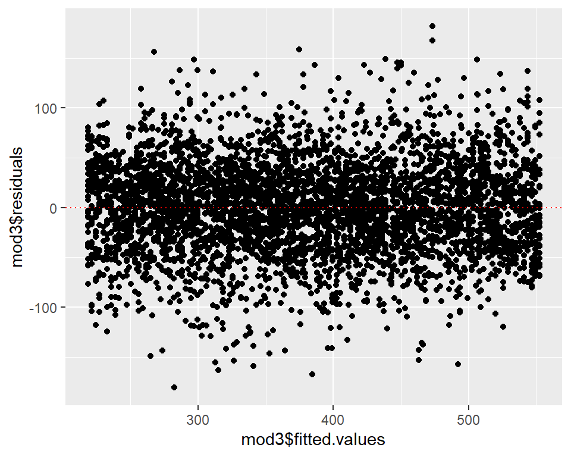

```r
ggplot(ddm_cln, aes(x = mod3$fitted.values, y = mod3$residuals)) +
  geom_point() +
  geom_hline(yintercept = 0, linetype = 3, colour = 'red')
```

Yes, the assumption is reasonable.

# Question 22

Using the preferred model. Evaluate whether the residuals are normally distributed. Is the assumption satisfied?

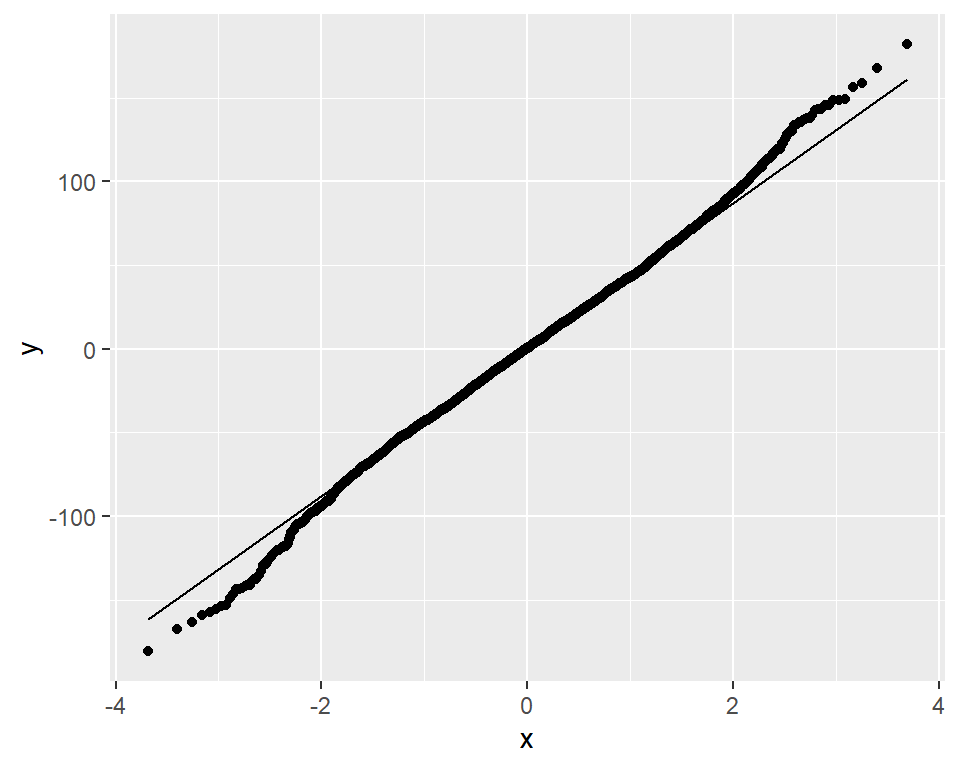

```r
ggplot(ddm_cln, aes(sample = mod3$residuals)) +
  stat_qq() +
  stat_qq_line()
```

Yes, the assumption is reasonable.

# Question 23

The data **“prisonBrain.csv”** shows the results of an experiment was performed to see whether sensory deprivation over an extended period of time has any effect on the alpha-wave patterns produced by the brain. To determine this, 20 subjects (inmates in a Canadian prison) were randomly split into two groups. Members of one group were placed in solitary confinement. Those in the other group were allowed to remain in their own cells. Seven days later, alpha-wave frequencies were measured for all subjects.

- *Source: P. Gendreau et al., “Changes in EEG Alpha Frequency and Evoked Response Latency During Solitary Confinement,” Journal of Abnormal Psychology 79 [1972]: 54–59)*

Find a way to convert the **prisonBrain.csv** dataset into the “tidy format” layout. Note: there is no one single way to do this, just find a way that works and print the results.

One possible (inelegant) method:

```r
brain <- read_csv("../Data/prisonBrain.csv")

#Column of condition names
condition <- c(rep("NonConfined", 10), rep("Confined", 10))

#Column of alpha-wave patterns
alpha_freq <- c(brain$NonConfined, brain$Confined)

#New dataframe
brain_tidy <- data.frame(condition, alpha_freq)
print(brain_tidy)
```

```
##      condition alpha_freq
## 1  NonConfined       10.7
## 2  NonConfined       10.7
## 3  NonConfined       10.4
## 4  NonConfined       10.9
## 5  NonConfined       10.5
## 6  NonConfined       10.3
## 7  NonConfined        9.6
## 8  NonConfined       11.1
## 9  NonConfined       11.2
## 10 NonConfined       10.4
## 11    Confined        9.6
## 12    Confined       10.4
## 13    Confined        9.7
## 14    Confined       10.3
## 15    Confined        9.2
## 16    Confined        9.3
## 17    Confined        9.9
## 18    Confined        9.5
## 19    Confined        9.0
## 20    Confined       10.9
```

Another (more elegant) way is to use the `stack()` function. It literally just “stacks” the columns you tell it to. This is only really useful for simple data sets like this.

```r
brain_tidy <- stack(brain, select = c("NonConfined", "Confined"))
print(brain_tidy)
```

```
##    values         ind
## 1    10.7 NonConfined
## 2    10.7 NonConfined
## 3    10.4 NonConfined
## 4    10.9 NonConfined
## 5    10.5 NonConfined
## 6    10.3 NonConfined
## 7     9.6 NonConfined
## 8    11.1 NonConfined
## 9    11.2 NonConfined
## 10   10.4 NonConfined
## 11    9.6    Confined
## 12   10.4    Confined
## 13    9.7    Confined
## 14   10.3    Confined
## 15    9.2    Confined
## 16    9.3    Confined
## 17    9.9    Confined
## 18    9.5    Confined
## 19    9.0    Confined
## 20   10.9    Confined
```

Possibly the most elegant way is to use the `pivot_longer()` function in the *tidyr* package, which is part of the [tidyverse](https://www.tidyverse.org/). This is excellent for more complicated data sets. It also outputs the data as a “tibble”.

```r
brain_tidy <- pivot_longer(brain,
  cols = 1:2,
  names_to = c("condition"), values_to = c("alpha_freq")
)
# The argument 'cols' indicates which columns to stack.
# 'names_to' and 'values_to' specify names for the new columns.
brain_tidy
```

```
## # A tibble: 20 × 2
##    condition   alpha_freq
##    <chr>            <dbl>
##  1 NonConfined       10.7
##  2 Confined           9.6
##  3 NonConfined       10.7
##  4 Confined          10.4
##  5 NonConfined       10.4
##  6 Confined           9.7
##  7 NonConfined       10.9
##  8 Confined          10.3
##  9 NonConfined       10.5
## 10 Confined           9.2
## 11 NonConfined       10.3
## 12 Confined           9.3
## 13 NonConfined        9.6
## 14 Confined           9.9
## 15 NonConfined       11.1
## 16 Confined           9.5
## 17 NonConfined       11.2
## 18 Confined           9
## 19 NonConfined       10.4
## 20 Confined          10.9
```